# Lab : Using Convolutional Neural Networks (CNN) to identify digits

### 4.2 - Add Dense layers on top

To complete our model, we will feed the last output tensor from the convolutional base (of shape (3, 3, 64)) into one or more Dense layers to perform classification. Dense layers take vectors as input (which are 1D), while the current output is a 3D tensor. First, we will flatten (or unroll) the 3D output to 1D, then add one or more Dense layers on top. MNIST has 10 output classes, so we use a final Dense layer with 10 outputs and a softmax activation.

```python
model.add(tf.keras.layers.Flatten())
model.add(tf.keras.layers.Dense(64, activation=tf.nn.relu))
model.add(tf.keras.layers.Dense(10, activation=tf.nn.softmax))

print(model.summary())
```

```
Model: "sequential"
_________________________________________________________________
Layer (type)                 Output Shape              Param #
=================================================================
conv2d (Conv2D)              (None, 26, 26, 32)        320
_________________________________________________________________
max_pooling2d (MaxPooling2D) (None, 13, 13, 32)        0
_________________________________________________________________
conv2d_1 (Conv2D)            (None, 11, 11, 64)        18496
_________________________________________________________________
max_pooling2d_1 (MaxPooling2 (None, 5, 5, 64)          0
_________________________________________________________________
conv2d_2 (Conv2D)            (None, 3, 3, 64)          36928
_________________________________________________________________
flatten (Flatten)            (None, 576)               0
_________________________________________________________________
dense (Dense)                (None, 64)                36928
_________________________________________________________________
dense_1 (Dense)              (None, 10)                650
=================================================================
Total params: 93,322
Trainable params: 93,322
Non-trainable params: 0
_________________________________________________________________
None
```

### 4.3 - Compile and Train

```python
model.compile(optimizer=tf.keras.optimizers.Adam(),  # 'adam'
              loss='sparse_categorical_crossentropy',
              metrics=['accuracy'])
```

## Step 5 - Setup Tensorboard

```python
## This is fairly boiler plate code

import datetime
import os

app_name = 'cnn-mnist' # you can change this, if you like

tb_top_level_dir= '/tmp/tensorboard-logs'
tensorboard_logs_dir= os.path.join (tb_top_level_dir, app_name,
                                    datetime.datetime.now().strftime("%Y-%m-%d--%H-%M-%S"))
print ("Saving TB logs to : " , tensorboard_logs_dir)

tensorboard_callback = tf.keras.callbacks.TensorBoard(log_dir=tensorboard_logs_dir, histogram_freq=1)
```

```
Saving TB logs to :  /tmp/tensorboard-logs/cnn-mnist/2019-09-09--19-56-53
```

## Step 6 : Train

```python
%%time

epochs = 10

print ("training starting ...")
history = model.fit(train_images, train_labels,
                    epochs=epochs, validation_split = 0.2, verbose=1,
                    callbacks=[tensorboard_callback])
print ("training done.")
```

```
training starting ...
Train on 48000 samples, validate on 12000 samples
WARNING:tensorflow:Entity <function Function._initialize_uninitialized_variables.<locals>.initialize_variables at 0x7f77c2b4acb0> could not be transformed and will be executed as-is. Please report this to the AutoGraph team. When filing the bug, set the verbosity to 10 (on Linux, `export AUTOGRAPH_V…
WARNING: Entity <function Function._initialize_uninitialized_variables.<locals>.initialize_variables at 0x7f77c2b4acb0> could not be transformed and will be executed as-is. Please report this to the AutoGraph team. When filing the bug, set the verbosity to 10 (on Linux, `export AUTOGRAPH_VERBOSITY=1…
training done.
CPU times: user 11min 52s, sys: 33 s, total: 12min 25s
Wall time: 1min 35s
```

## Step 7 : See Training History

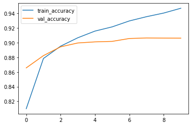

```python
%matplotlib inline
import matplotlib.pyplot as plt

plt.plot(history.history['accuracy'], label='train_accuracy')
plt.plot(history.history['val_accuracy'], label='val_accuracy')
plt.legend()
plt.show()
```

## Step 8 - Predict

**==> Compare prediction time vs training time. Prediction is very quick!**

```python
%%time

print ("predicting on {:,} images".format(len(test_images)))
predictions = model.predict(test_images)
```

```
predicting on 10,000 images
CPU times: user 3 s, sys: 89.5 ms, total: 3.09 s
Wall time: 477 ms
```

```
random index =  8249
test_label[8249] = 7.  So the number is 7
prediction of test_image[8249] = [ 0.000  0.000  0.000  0.000  0.000  0.000  0.000  1.000  0.000  0.000]
max softmax output =  0.9999999
index of max softmax output = 7.  So the prediction is same (7)
```

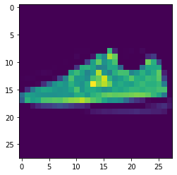

```python
## Print a sample prediction

%matplotlib inline
import matplotlib.pyplot as plt
import random
import numpy as np
from pprint import pprint

np.set_printoptions(formatter={'float': '{: 0.3f}'.format})

index = random.randint(0, len(test_images))

print ("random index = ", index)
print ("test_label[{}] = {}.  So the number is {}".format(index, test_labels[index], test_labels[index]))
print ("prediction of test_image[{}] = {}".format(index, predictions[index]))
print ('max softmax output = ', np.amax(predictions[index]))
print ('index of max softmax output = {}.  So the prediction is same ({})'.format(np.argmax(predictions[index]), np.argmax(predictions[index])))

plt.imshow(test_images2[index])
```

## Step 9 : Evaluate the Model

### 9.1 - Metrics

```python
metric_names = model.metrics_names
print ("model metrics : " , metric_names)

metrics = model.evaluate(test_images, test_labels, verbose=0)

for idx, metric in enumerate(metric_names):
    print ("Metric : {} = {:,.3f}".format (metric_names[idx], metrics[idx]))
```

```
model metrics :  ['loss', 'accuracy']
Metric : loss = 0.314
Metric : accuracy = 0.904
```

### 9.2 - Confusion Matrix

```python
## our predictions is an array of arrays
print('predictions shape : ', predictions.shape)
print ('prediction 0 : ' , predictions[0])
print ('prediction 1 : ' , predictions[1])
```

```
predictions shape :  (10000, 10)
prediction 0 :  [ 0.000  0.000  0.000  0.000  0.000  0.000  0.000  0.000  0.000  1.000]
prediction 1 :  [ 0.000  0.000  1.000  0.000  0.000  0.000  0.000  0.000  0.000  0.000]
```

```python
## We need to find the final output (max of softmax probabilities for each prediction)
predictions2 = [ np.argmax(p) for p in predictions]
print ('prediction2 0 : ' , predictions2[0])
print ('prediction2 1 : ' , predictions2[1])
```

```
prediction2 0 :  9
prediction2 1 :  2
```

```python
from sklearn.metrics import confusion_matrix
import seaborn as sns

cm = confusion_matrix(test_labels, predictions2, labels = [0,1,2,3,4,5,6,7,8,9])
cm
```

```
array([[830,   0,  11,  34,   2,   0, 116,   0,   7,   0],
       [  2, 975,   0,  17,   1,   0,   2,   0,   3,   0],
       [ 18,   2, 847,  14,  58,   0,  54,   0,   7,   0],
       [  7,   6,   6, 940,  22,   0,  16,   0,   3,   0],
       [  2,   1,  44,  42, 877,   0,  30,   0,   4,   0],
       [  0,   0,   0,   1,   0, 983,   0,  13,   0,   3],
       [ 96,   1,  62,  36,  96,   0, 698,   0,  11,   0],
       [  0,   0,   0,   0,   0,  15,   0, 959,   0,  26],
       [  5,   0,   1,   3,   2,   3,   3,   4, 979,   0],
       [  1,   0,   0,   0,   0,  14,   0,  34,   0, 951]])
```

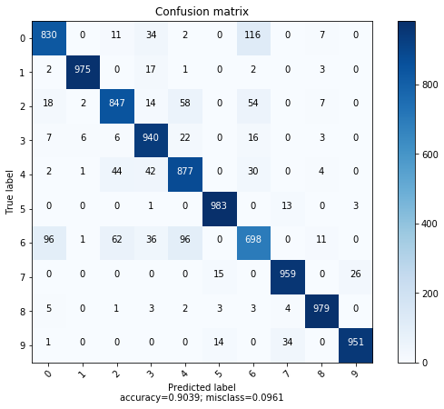

```python
## Plot confusion matrix
import os
import sys
top_dir = os.path.abspath(os.path.join(os.getcwd(), "../"))
if top_dir not in sys.path:
    sys.path.append(top_dir)

import my_utils

my_utils.plot_confusion_matrix(cm, target_names=[0,1,2,3,4,5,6,7,8,9], normalize=False)
```

### 9.3 - Metrics Calculated from Confusion Matrix

```python
from sklearn.metrics import classification_report
from pprint import pprint

pprint(classification_report(test_labels, predictions2, output_dict=True))
```

```
{'0': {'f1-score': 0.8465068842427332,
       'precision': 0.8636836628511967,
       'recall': 0.83,
       'support': 1000},
 '1': {'f1-score': 0.982367758186398,
       'precision': 0.9898477157360406,
       'recall': 0.975,
       'support': 1000},
 '2': {'f1-score': 0.8594622019279553,
       'precision': 0.8722966014418125,
       'recall': 0.847,
       'support': 1000},
 '3': {'f1-score': 0.9008145663632008,
       'precision': 0.8647654093836247,
       'recall': 0.94,
       'support': 1000},
 '4': {'f1-score': 0.8522837706511176,
       'precision': 0.8289224952741021,
       'recall': 0.877,
       'support': 1000},
 '5': {'f1-score': 0.975682382133995,
       'precision': 0.9684729064039409,
       'recall': 0.983,
       'support': 1000},
 '6': {'f1-score': 0.7274622199062012,
       'precision': 0.7595212187159956,
       'recall': 0.698,
       'support': 1000},
 '7': {'f1-score': 0.9542288557213929,
       'precision': 0.9495049504950495,
       'recall': 0.959,
       'support': 1000},
 '8': {'f1-score': 0.9721946375372393,
       'precision': 0.965483234714004,
       'recall': 0.979,
       'support': 1000},
 '9': {'f1-score': 0.9606060606060605,
       'precision': 0.9704081632653061,
       'recall': 0.951,
       'support': 1000},
 'accuracy': 0.9039,
 'macro avg': {'f1-score': 0.9031609337276294,
               'precision': 0.9032906358281073,
               'recall': 0.9038999999999999,
               'support': 10000},
 'weighted avg': {'f1-score': 0.9031609337276293,
                  'precision': 0.9032906358281074,
                  'recall': 0.9039,
                  'support': 10000}}
```

## Step 10 : Improve the Model

Try the following exercises

**1 - Increase epochs**